# Getting comfortable with ggplot2

October 23, 2015

https://github.com/dnedveck/HALICON2015

## Who am I

- PhD candidate in Plant Biological Sciences, University Minnesota-Twin Cities
- Thesis on mutalistic interactions
- genomics, greenhouse experiments
- Quantified Self: time, weight, sleep, activity (walking, biking)

## What am I going to cover

- Philosophy of `ggplot2`
- graphing
- colors
- themes

## setting the stage

## Hadleyverse

Data science toolkit in R

a focus on the `data.frame`/`tbl_df`

- `ggplot2`
- `dplyr`
- `tidyr`
- `lubridate`

also: `knitr`

## plotting systems

base `R` = paper and pencil

`ggplot2` = abstraction - layers, transformations, etc. and this gets translated to "paper and pencil"

## Grammar of Graphics

## Parts of a graph

- `data`
- `aes`thetic
- `geom`etric objects
- `stat`istic

these all come together to make up a `layer`

## different types of layers

- data
- summary / stat
- metadata - map, annotations

## Describing a graph with our new vocab

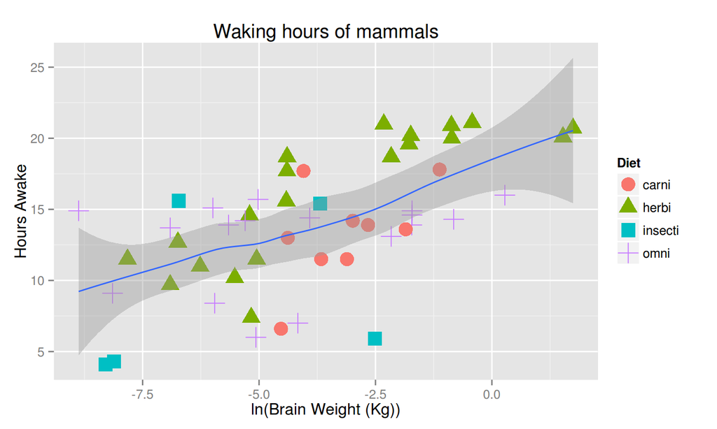

## Building a plot in `ggplot2`

## `iris` data

- included dataset in base R
- flower morphology for three speices of iris – sepals and petals

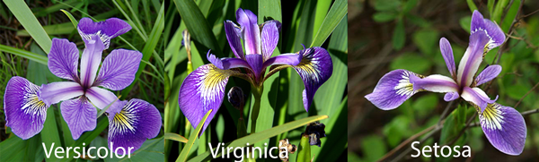

*Brett Bond*

<sup>*taken from: http://articles.concreteinteractive.com/machine-learning-a-new-tool-for-humanity/*</sup>

## A simple plot

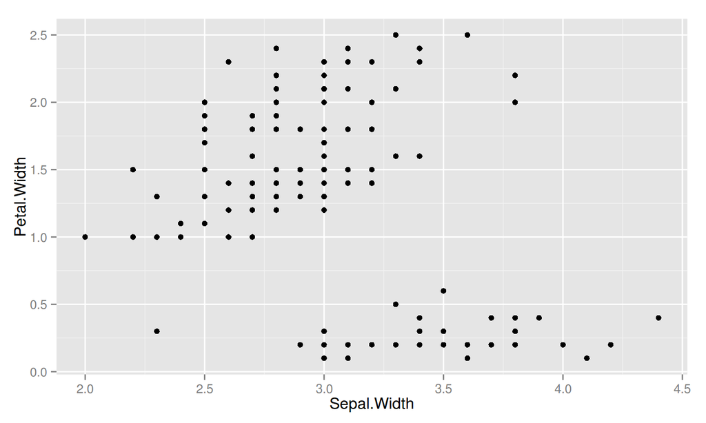

```r
ggplot(iris, aes(x = Sepal.Width, y = Petal.Width)) +
  geom_point()
```

## Let's add color

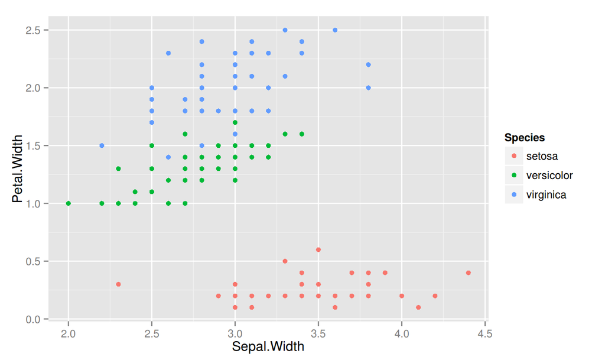

```r
ggplot(iris, aes(x = Sepal.Width, y = Petal.Width)) +
  geom_point(aes(color = Species))
```

<sup>*let's take a moment to appreciate the automatically generated legend*</sup>

## Using stat

Adding a linear regression lines based on species

```r
ggplot(iris, aes(x = Sepal.Width, y = Petal.Width)) +
  geom_point(aes(color = Species)) +
  stat_smooth(method="lm", aes(color = Species))
```

## Using stat

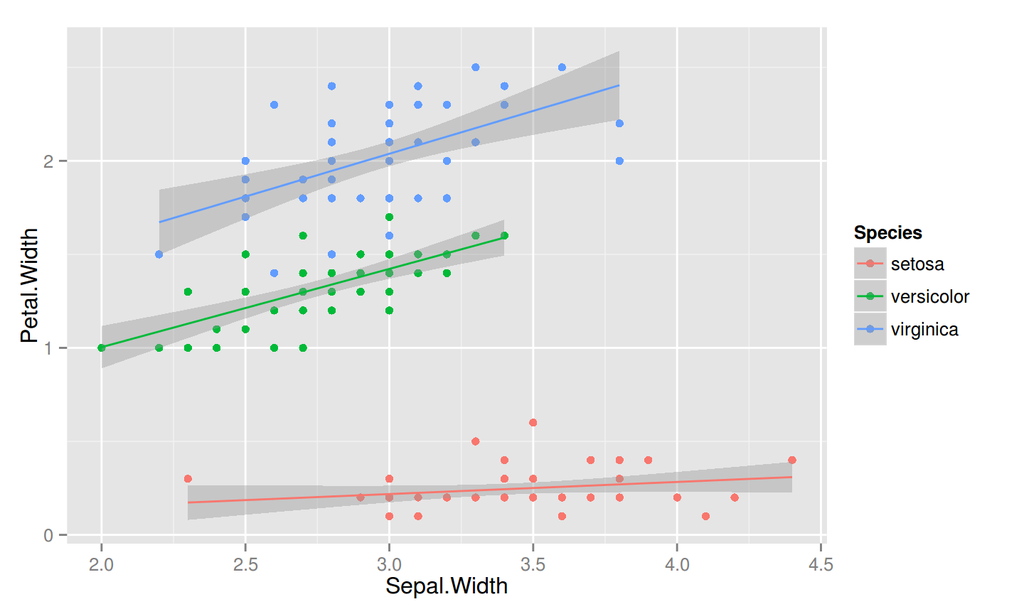

## Facets

## `facet_wrap`

makes a ribbon

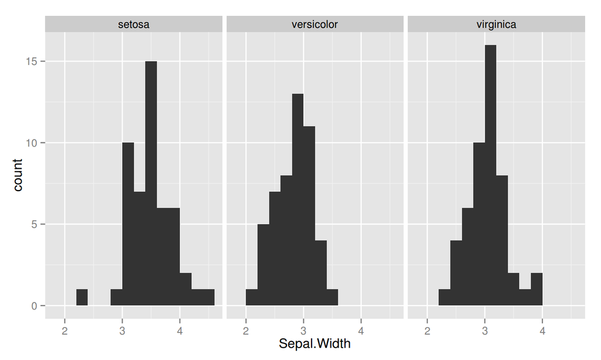

```r
ggplot(iris, aes(x = Sepal.Width)) +
  geom_histogram(binwidth = 0.2) +
  facet_wrap( ~ Species)
```

## `facet_grid`

takes two variables

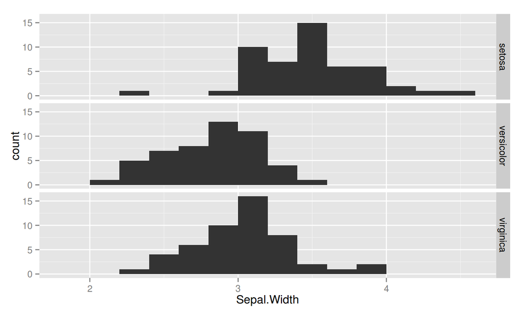

```r
ggplot(iris, aes(x = Sepal.Width)) +
  geom_histogram(binwidth = 0.2) +
  facet_grid(Species ~ .)
```

## Arranging plots

unfortunately there's no way to arrange plots included in `ggplot2`, but there is:

```r
library(gridExtra)
```

```r
grid.arrange()
```

## Save your plots as objects

```r
g.sepal <- ggplot(iris, aes(x = Sepal.Width, y = Sepal.Length)) +
  geom_point(aes(color = Species)) +
  labs(title = "Sepal Scatter plot")

g.petal <- ggplot(iris, aes(x = Petal.Width, y = Petal.Length)) +
  geom_point(aes(color = Species)) +
  labs(title = "Petal Scatter plot")
```

## Then plot

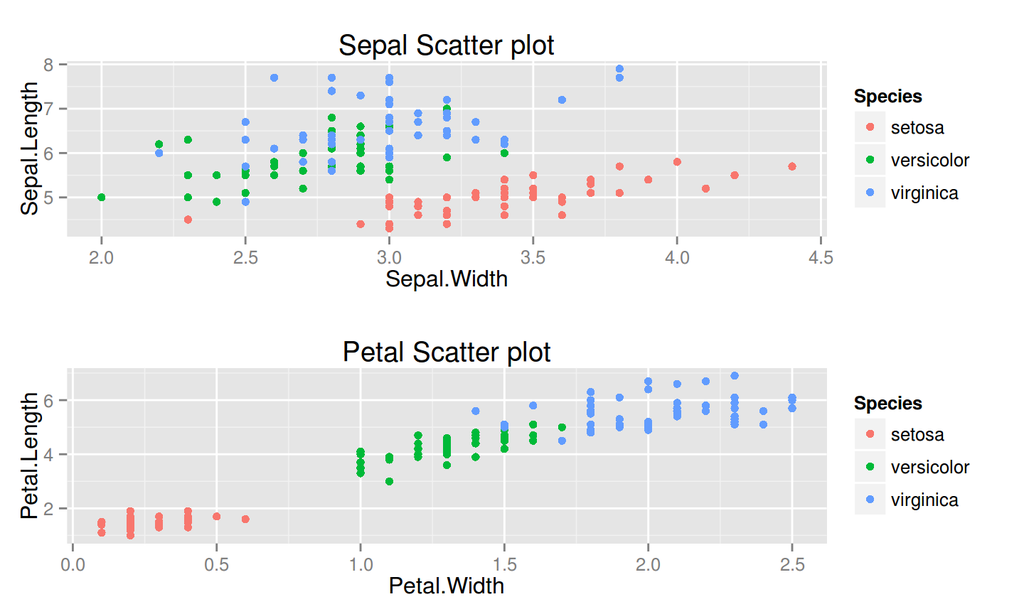

```r
grid.arrange(g.sepal, g.petal)
```

## Defining Color Palettes

## changing your color palette

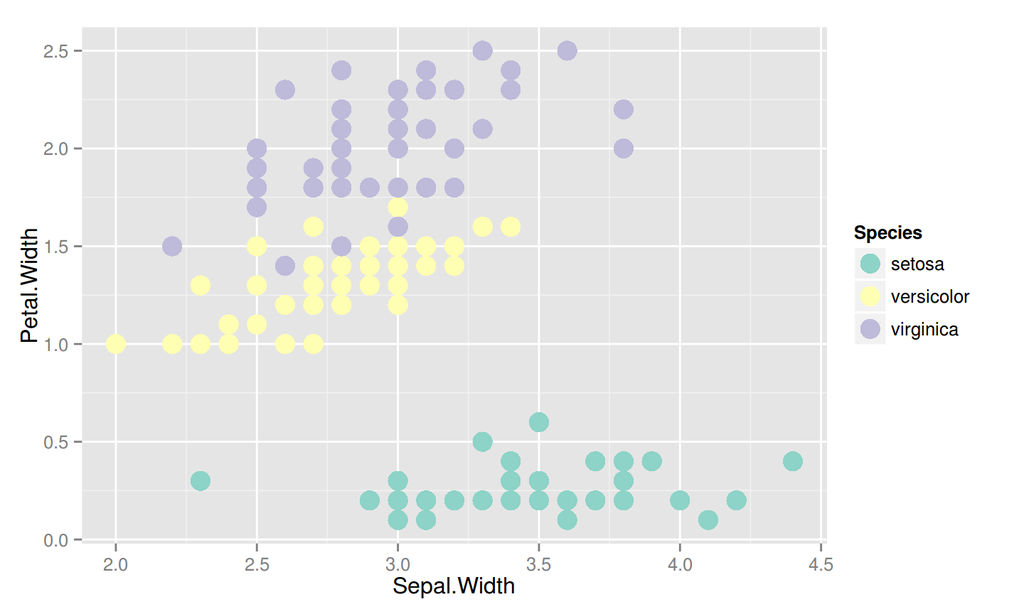

```r
ggplot(iris, aes(x = Sepal.Width, y = Petal.Width)) +
  geom_point(aes(color = Species), size = 5) +
  scale_color_brewer(palette = "Set3")
```

## built in color palettes from `RColorBrewer`

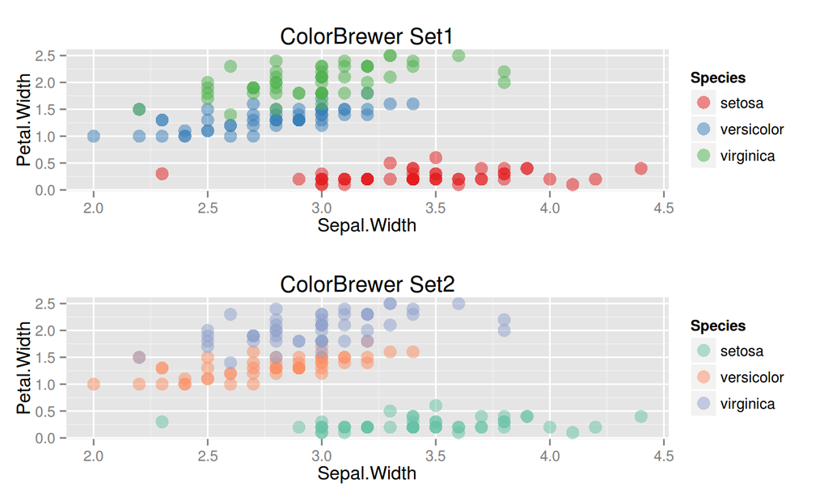

## What if you have a specific color scheme that you want to work with?

```r
scale_color_manual(values = c("#1BE7FF", "#6EEB83", "#FF9502"))
scale_color_gradient(low = "#397DD3", high = "#FF9502")
```

## Here's that manual palette I defined

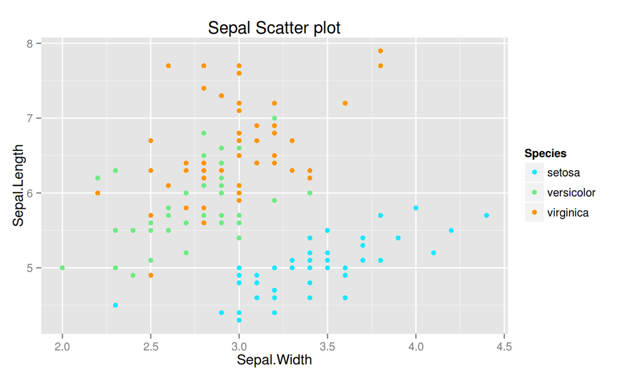

```r
g.sepal + scale_color_manual(values = c("#1BE7FF", "#6EEB83", "#FF9502"))
```

## Using Themes

## changing your theme

```r
ggplot(iris, aes(x = Sepal.Width, y = Petal.Width)) +
  geom_point(aes(color = Species)) +
  stat_smooth(method="lm", aes(color = Species)) +
  theme_bw()
```

## changing your theme

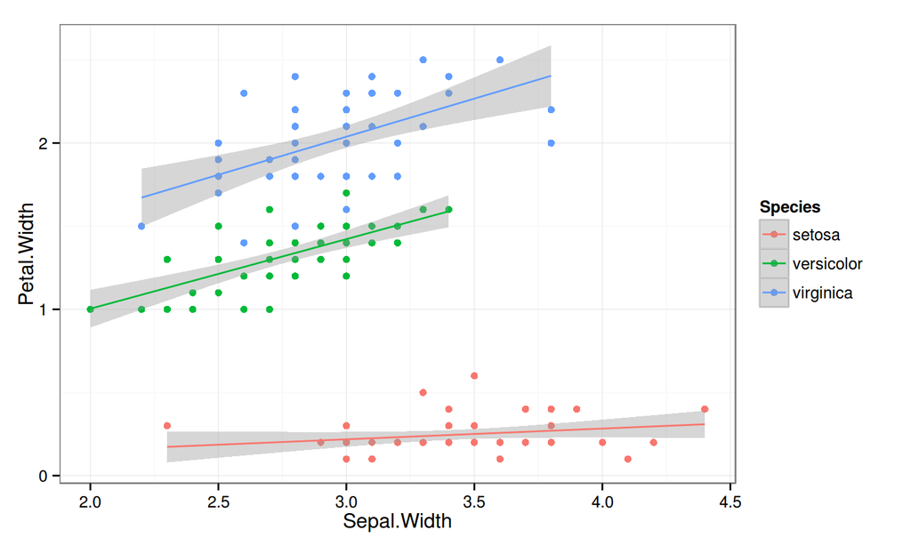

## what themes look like

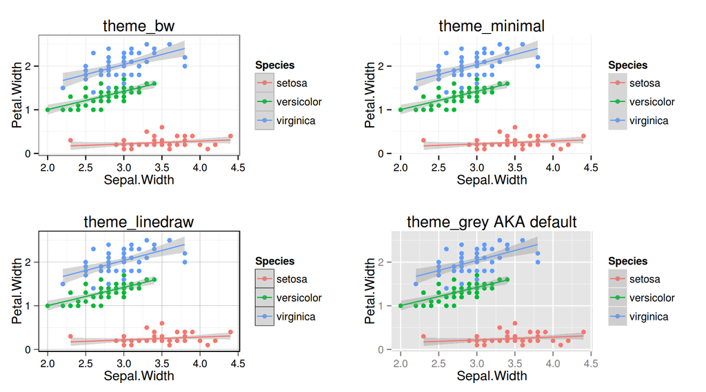

## defining your own theme

```r
theme_dned <- theme_bw() +
  theme(axis.text = element_text(size = rel(0.8),colour = "grey50"),
        plot.title = element_text(size = rel(1.2)),
        panel.grid.major = element_line(colour = "#643B0F"),
        panel.grid.minor = element_line(colour = NA ),
        panel.background = element_rect( fill = "#EFE0B9" ),
        plot.background = element_rect(fill = "#FFFFF0"))
```

## Setting themes

```r
theme_set(theme_dned)
```

now you don't have to keep adding `+ theme_dned()` to each plot

## plot with new set theme

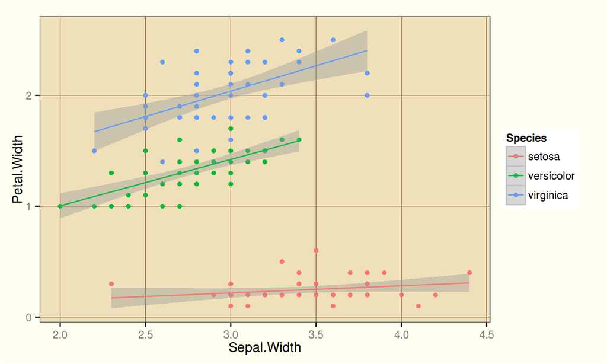

```r
ggplot(iris, aes(x = Sepal.Width, y = Petal.Width)) +
  geom_point(aes(color = Species)) +
  stat_smooth(method="lm", aes(color = Species))
```

## How to know what you can modify

Look inside one:

```r
theme_bw
```

```
## function (base_size = 12, base_family = "")
## {
##     theme_grey(base_size = base_size, base_family = base_family) %+replace%
##         theme(axis.text = element_text(size = rel(0.8)), axis.ticks = element_line(colour = "black"),
##             legend.key = element_rect(colour = "grey80"), panel.background = element_rect(fill = "white",
##                 colour = NA), panel.border = element_rect(fill = NA,
##                 colour = "grey50"), panel.grid.major = element_line(colour = "grey90",
##                 size = 0.2), panel.grid.minor = element_line(colour = "grey98",
##                 size = 0.5), strip.background = element_rect(fill = "grey80",
##                 colour = "grey50", size = 0.2))
## }
## <environment: namespace:ggplot2>
```

## How to know what you can modify

Look inside one:

also see `theme_grey.r` in the GitHub repo for a nicely formatted one.

## There's also a ton more premade ones

ggthemes: https://github.com/jrnold/ggthemes

```r
library(ggthemes)
```

… which includes a couple geoms, themes, and colors. It's nice.

## Going out and doing your own plotting

## Here's some resources

Cookbooks / cheatsheets

- [`ggplot2` docs](http://docs.ggplot2.org/current/)
- Zev Ross' [ggplot2 Cheatsheet](http://zevross.com/blog/2014/08/04/beautiful-plotting-in-r-a-ggplot2-cheatsheet-3/)
- Winston Chang's [Cookbook for R](http://www.cookbook-r.com/Graphs/)
- [`ggplot2` GitHub repo](https://github.com/hadley/ggplot2) – it's still under active development

## Books

- [R Graphics Cookbook by Winston Chang](http://amzn.to/1GR9bGg)
- [ggplot2 book by Hadley Wickham](http://amzn.to/1ZUNAbB)